# ANR Phytovirus - plants

Oumaima Moubset, Virginie Ravigné, Frédéric Mahé

09 novembre 2022

#### Load packages

```r
library(readxl)
library(tidyverse)
library(janitor)
library(purrr)
library(ggplot2)
```

## Generate the plant and quadrat data sets from field reports in data

Summaries of the plant and the quadrat data sets.

```r
source("./scripts/Distrib_cover_fred.R")
plant_data %>%
  select(
    Year,
    Locality,
    Grid,
    Quadrat,
    Vegetation,
    Total_cover,
    Total_cover_max,
    Plant_richness,
    Plant_diversity
  ) %>%
  distinct() -> quadrat_data

quadrat_data %>% summary()
```

```
##      Year             Locality             Grid             Quadrat
##  Length:252         Length:252         Length:252         Length:252
##  Class :character   Class :character   Class :character   Class :character
##  Mode  :character   Mode  :character   Mode  :character   Mode  :character
##
##
##
##
##    Vegetation      Total_cover     Total_cover_max  Plant_richness
##  Min.   : 15.00   Min.   : 10.00   Min.   : 15.00   Min.   : 1.000
##  1st Qu.: 40.00   1st Qu.: 50.38   1st Qu.: 73.25   1st Qu.: 3.000
##  Median : 70.00   Median : 78.00   Median :100.00   Median : 4.000
##  Mean   : 66.68   Mean   : 75.63   Mean   : 98.18   Mean   : 5.619
##  3rd Qu.: 87.50   3rd Qu.: 94.50   3rd Qu.:120.00   3rd Qu.: 7.000
##  Max.   :100.00   Max.   :198.00   Max.   :255.00   Max.   :27.000
##  NA's   :45
##  Plant_diversity
##  Min.   : 1.000
##  1st Qu.: 1.740
##  Median : 2.380
##  Mean   : 3.176
##  3rd Qu.: 3.832
##  Max.   :15.126
##
```

```r
plant_data %>% summary()
```

```
##     Plant             Quadrat              Year             Locality
##  Length:1416        Length:1416        Length:1416        Length:1416
##  Class :character   Class :character   Class :character   Class :character
##  Mode  :character   Mode  :character   Mode  :character   Mode  :character
##
##
##
##
##      Grid           Cover_classes     Cover_max        Vegetation
##  Length:1416        Min.   : 0.50   Min.   :  1.00   Min.   : 15.0
##  Class :character   1st Qu.: 0.50   1st Qu.:  1.00   1st Qu.: 50.0
##  Mode  :character   Median : 3.00   Median :  5.00   Median : 70.0
##                     Mean   :13.46   Mean   : 17.47   Mean   : 67.1
##                     3rd Qu.:20.00   3rd Qu.: 25.00   3rd Qu.: 87.5
##                     Max.   :87.50   Max.   :100.00   Max.   :100.0
##                                                      NA's   :241
##   Total_cover     Relative_abundance Total_cover_max Plant_richness
##  Min.   : 10.00   Min.   :0.00339    Min.   : 15.0   Min.   : 1.000
##  1st Qu.: 51.00   1st Qu.:0.01429    1st Qu.: 77.0   1st Qu.: 4.000
##  Median : 71.50   Median :0.05882    Median :100.0   Median : 7.000
##  Mean   : 74.53   Mean   :0.17797    Mean   :100.4   Mean   : 8.586
##  3rd Qu.: 93.50   3rd Qu.:0.22989    3rd Qu.:121.0   3rd Qu.:10.000
##  Max.   :198.00   Max.   :1.00000    Max.   :255.0   Max.   :27.000
##
##  Plant_diversity       Rank        Plant_genus
##  Min.   : 1.000   Min.   : 1.000   Length:1416
##  1st Qu.: 2.283   1st Qu.: 2.000   Class :character
##  Median : 3.541   Median : 3.000   Mode  :character
##  Mean   : 4.617   Mean   : 4.793
##  3rd Qu.: 6.378   3rd Qu.: 6.000
##  Max.   :15.126   Max.   :27.000
##
```

# Exploring plant distributions

## Distribution of total cover

Total plant cover in quadrats may be measured in different ways. A Vegetation index is pifometrically measured in situ. It should more or less relate to Total_cover, the sum of the mean of the cover ranges over all plants, and Total_cover_max, the sum of the superior limit of cover ranges over plants. Total_cover and Total_cover_ max should not be less than Vegetation. Values of Total_cover and Total_cover_ max exceeding Vegetation could indicate that plants are disposed into several layers.

Total_cover and Vegetation correlate nicely :

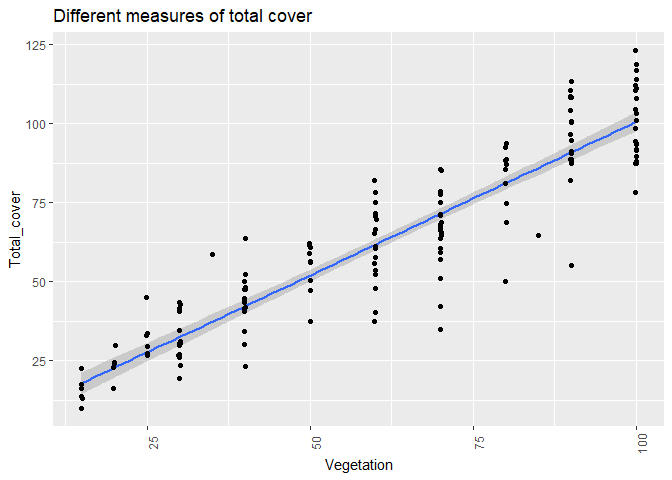

```r
quadrat_data %>%
  filter(Locality == "CAM") %>%
  ggplot(., aes(x = Vegetation, y = Total_cover)) +
  geom_smooth(method = "lm", se = T) +
  geom_point(position = position_jitter(0.1)) +
  theme(axis.text.x = element_text(angle = 90)) +
  ggtitle("Different measures of total cover")
```

```r
# quadrat_data %>%
#   filter(Locality == "CAM") %>%
#   ggplot(., aes(x = Vegetation, y = Total_cover_max)) +
#   geom_smooth(method = "lm", se = T) +
#   geom_point(position = position_jitter(0.1)) +
#   theme(axis.text.x = element_text(angle = 90))
```

Distribution of total cover over grids :

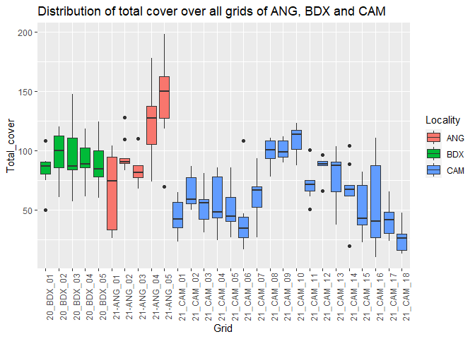

```r
ggplot(quadrat_data, aes(fill = Locality, y = Total_cover, x = Grid)) +
  geom_boxplot(position = "dodge") +
  theme(axis.text.x = element_text(angle = 90)) +
  ggtitle("Distribution of total cover over all grids of ANG, BDX and CAM")
```

```r
# An alternative visualization with an frequency histogram
# ggplot(quadrat_data, aes(x = Total_cover, fill = Locality)) +
#   geom_histogram(position = "dodge") +
#   ggtitle("Distribution of total cover over all grids of ANG, BDX and CAM")
```

## Ranges of observed plant richness and diversity

NB : Richness as a number of plant species. Diversity as a Hill number of order 1 (i.e., exp(Shannon)).

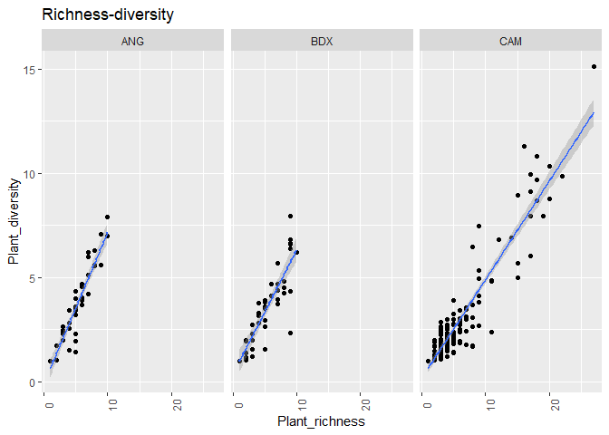

```r
# All localities grouped together
# ggplot(quadrat_data, aes(x = Plant_richness, y = Plant_diversity)) +
#   geom_point() +
#   geom_smooth(method = "lm", se = T) +
#   theme(axis.text.x = element_text(angle = 90)) +
#   ggtitle("Richness-diversity")

#By locality
ggplot(quadrat_data, aes(x = Plant_richness, y = Plant_diversity)) +
  geom_point() +
  geom_smooth(method = "lm", se = T) +
  theme(axis.text.x = element_text(angle = 90)) +
  facet_grid(~ Locality) +
  ggtitle("Richness-diversity")
```

NB : It could be good to check the outlier at > 25 species. Maybe Hugo took too much coffee that day…

## Distributions of abundances

Cover ranges can be viewed as measures of absolute abundance. Here the variable Cover_classes accounts for the means of cover ranges.

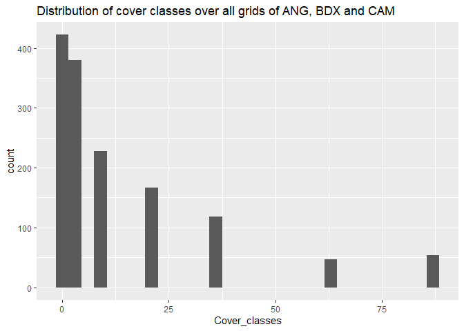

```r
ggplot(plant_data, aes(x = Cover_classes)) +
  geom_histogram() +
  ggtitle("Distribution of cover classes over all grids of ANG, BDX and CAM")
```

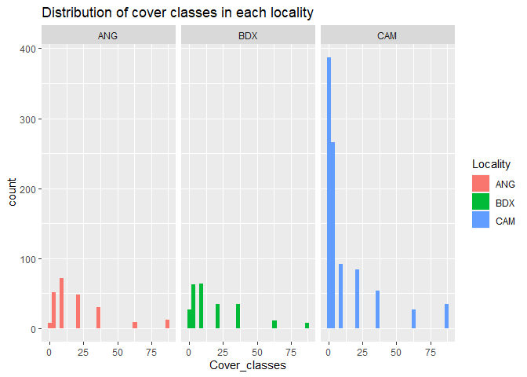

```r
ggplot(plant_data, aes(x = Cover_classes, fill = Locality)) +
  geom_histogram() +
  facet_grid( ~ Locality) +
  ggtitle("Distribution of cover classes in each locality")
```

Following a bold inspiration, let’s compute relative abundances using the normalized Cover_classes (Cover_classes/sum(Cover_classes) for each plant in a quadrat):

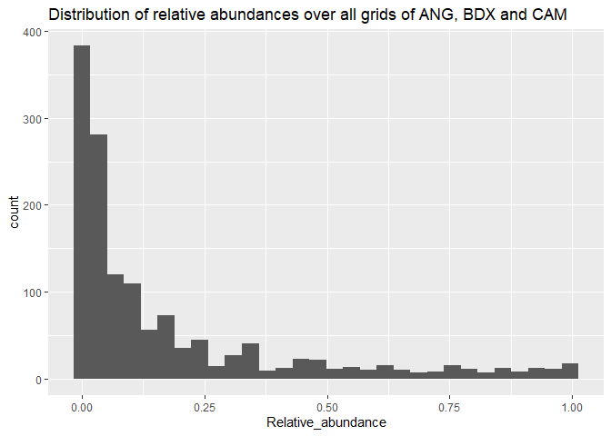

```r
ggplot(plant_data, aes(x = Relative_abundance)) +
  geom_histogram() +
  ggtitle("Distribution of relative abundances over all grids of ANG, BDX and CAM")
```

Now we take the log10 of this relative abundance. If the distribution is flat, relative abundance follows a 1/x function (Barbier, pers. comm.):

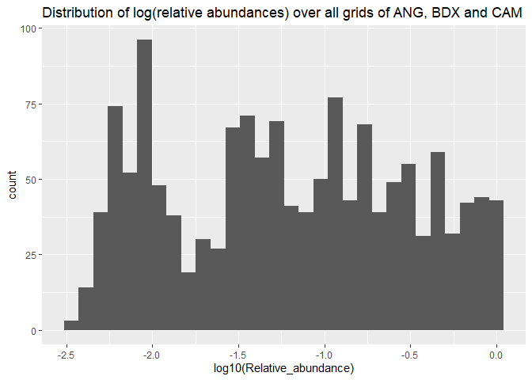

```r
ggplot(plant_data, aes(x = log10(Relative_abundance))) +
  geom_histogram() +
  ggtitle("Distribution of log(relative abundances) over all grids of ANG, BDX and CAM")
```

Matthieu says that this is flat. Philippe would probably see a cosinus. Other opinions?

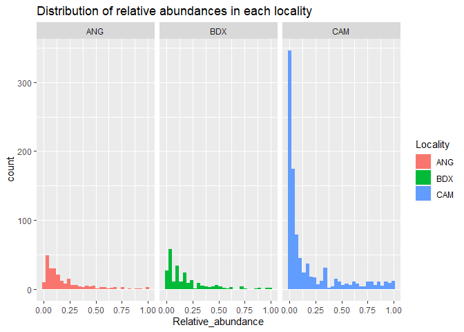

```r
ggplot(plant_data, aes(x = Relative_abundance, fill = Locality)) +
  geom_histogram() +
  facet_grid( ~ Locality) +
  ggtitle("Distribution of relative abundances in each locality")
```

Team blue wins.